# Data Visualization II

Loading libraries:

```r
library(ggplot2)
library(tidyverse)
```

Importing data:

```r
names <- read_csv("namestib.csv")
```

Starting from what I think was the most successful of the visualizations I produced previously:

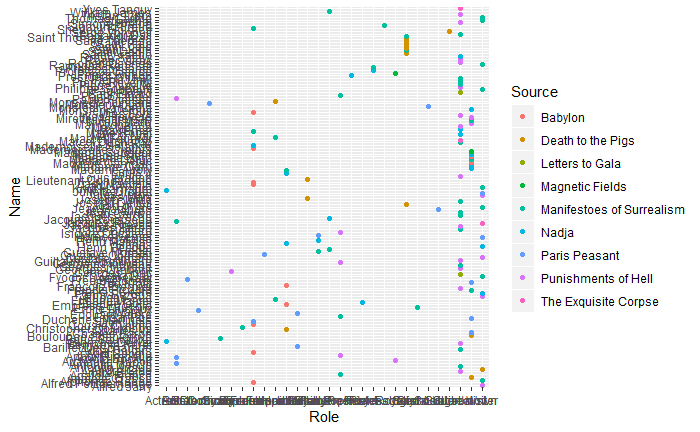

```r
ggplot(data = names) +
 geom_point(mapping = aes(x = Role, y = Name, color = Source))
```

Working with a slightly different dataset

```r
roles <- read_csv("rolestib.csv")
rolestib <- as_tibble(roles)
```

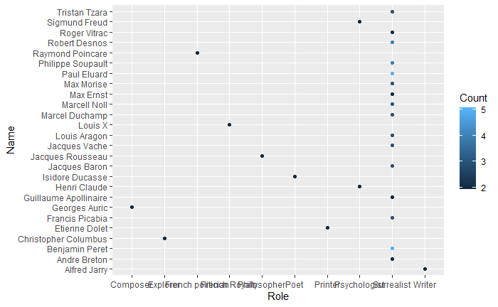

```r
ggplot(data = rolestib) +
  geom_point(mapping = aes(x = Role, y = Name, color = Count))
```

This dataset is a lot more manageable. It only contains the names that were mentioned in more than one sources, but I feel like the Count variable is not represented properly, and there’s still a lot of blank space on the left-hand side of the chart.

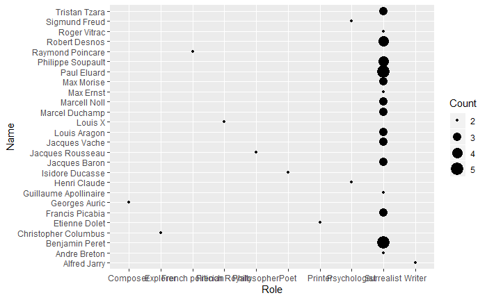

```r
ggplot(data = rolestib) +
  geom_point(mapping = aes(x = Role, y = Name, size = Count))
```

Trying something from the Internet to reorder varaiable:

```r
library(forcats)
```

```r
rolestib %>%
  mutate(Role = fct_reorder(Role, val)) %>%
  ggplot(data = rolestib) +
  geom_point(mapping = aes(x = Role, y = Name, size = Count))
```

```
Error: Problem with `mutate()` input `Role`.
x object 'val' not found
i Input `Role` is `fct_reorder(Role, val)`.
```

Hmm maybe not worth my time to figure that out. Bar chart?

```r
rolestib %>%
  ggplot(aes(x = Role, y = Count)) +
  geom_bar(stat="Count")
```

That didn’t really work out. Let’s try again.

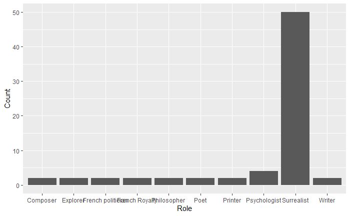

```r
ggplot(data = rolestib) +
  geom_bar(mapping = aes(x = Role, y = Count), stat = "identity", position = "stack")
```

Trying a new table with more people included but excluding all of the Surrealists, as I’ve already shown that group is over-represented in this corpus.

```r
nrcsur <- read_csv("nrcsur.csv")
nstib <- as_tibble(nrcsur)
```

[output not shown]

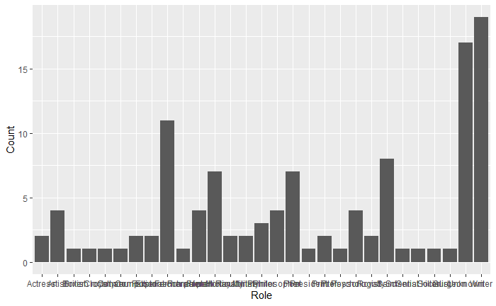

```r
ggplot(data = nstib) +
  geom_bar(mapping = aes(x = Role, y = Count), stat = "identity", position = "stack", horiz = TRUE)
```

Trying to reorder variables:

```r
library(scales)
```

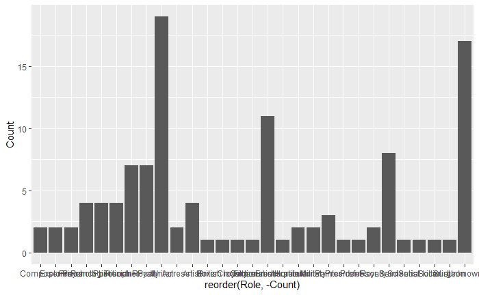

```r
ggplot(nstib, aes(x = reorder(Role, -Count), y = Count)) +
  geom_bar(stat = "identity")
```

None of that works, so I’m just going to call it a day and make it look nicer.

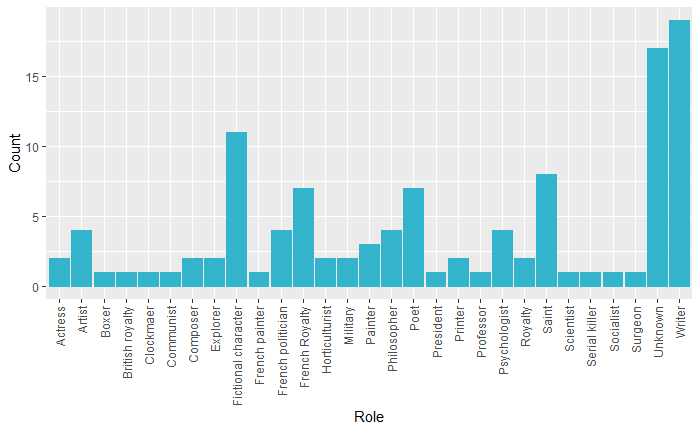

```r
ggplot(nstib, aes(x = Role, y = Count)) +
  geom_bar(stat = "identity", color=rgb(0.2, 0.7, 0.8), fill=rgb(0.2, 0.7, 0.8)) +
  theme(axis.text.x = element_text(angle = 90, vjust = 0.5, hjust=1))
```

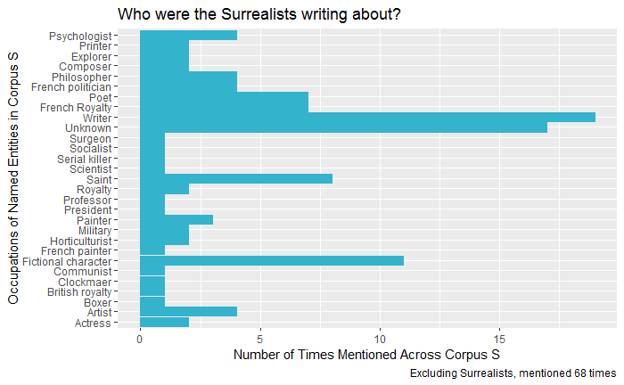

```r
ggplot(nstib, aes(x = reorder(Role, Count), y = Count)) +
  geom_bar(stat = "identity", color=rgb(0.2, 0.7, 0.8), fill=rgb(0.2, 0.7, 0.8)) +
  coord_flip() +
  labs(x = "Occupations of Named Entities in Corpus S", y = "Number of Times Mentioned Across Corpus S",
       caption = "Excluding Surrealists, mentioned 68 times",
       title = "Who were the Surrealists writing about?")
```

```r
ggsave(filename = "roles.png", width = 7, height = 5)
```

I like this graph. I feel like it communicates how many people of each role were mentioned across this corpus. I want to try this with the names data from before.

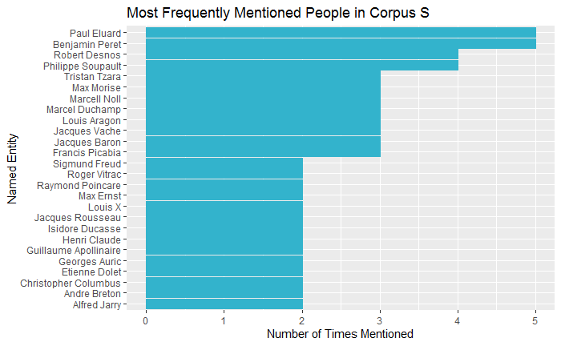

```r
ggplot(rolestib, aes(x = reorder(Name, Count), y = Count)) +
  geom_bar(stat = "identity", color=rgb(0.2, 0.7, 0.8), fill=rgb(0.2, 0.7, 0.8)) +
  coord_flip() +
  labs(x = "Named Entity", y = "Number of Times Mentioned",
       title = "Most Frequently Mentioned People in Corpus S")
```

```r
ggsave(filename = "freq.png", width = 7, height = 5)
```

I don’t love that this doesn’t include the roles of each person and that I can’t change the label of the x axis–just kidding about the labels! Trying one last thing.

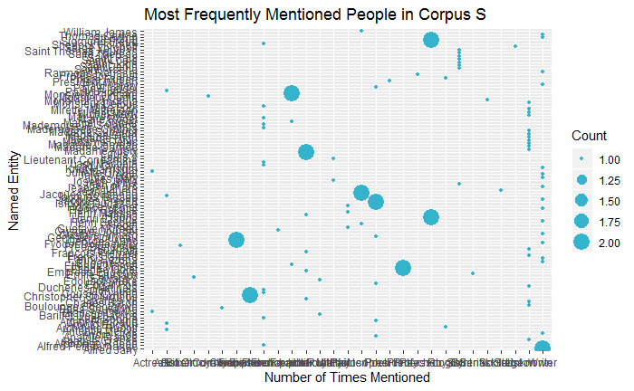

```r
ggplot(data = nstib) +
  geom_point(mapping = aes(x = Name, y = Role, size = Count), color=rgb(0.2, 0.7, 0.8), fill=rgb(0.2, 0.7, 0.8)) +
  coord_flip() +
  labs(x = "Named Entity", y = "Number of Times Mentioned",
       title = "Most Frequently Mentioned People in Corpus S")
```

Not that great. I’m happy with two charts I was able to create.